# Data Viz 2: Mapping Areas and Context

```r
#note that you need to run both cells at the same time, otherwise you will get an error.
```

Another feature that is very common to see on a map is a legend which tells you what values the colors used on the map correspond to.

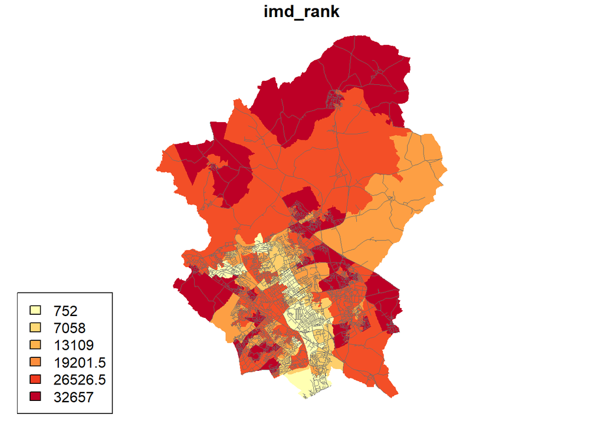

```r
# Plot choropleth
plot(LSOA["imd_rank"],col=colours_to_map,border = NA, reset = FALSE)
plot(st_geometry(roads),col="#6B6B6B",lwd=0.3, add=TRUE)
# Add legend
#legend("bottomleft", legend =c("a","b","c","d","e","f"), fill = my_colours)
legend("bottomleft", legend =breaks$brks, fill = my_colours)
```

```r
breaks
```

```
## style: fisher
##   one of 20,811,575 possible partitions of this variable into 5 classes
##        [752,7058)      [7058,13109)   [13109,19201.5) [19201.5,26526.5)
##                21                22                24                54
##   [26526.5,32657]
##                31
```

We will now add some points to the map by creating a new Spatial Points Data Frame as we demonstrated in the previous practical (see 2. Data Manipulation in R):

```r
#Read in the location of schools
schools <- read.csv("./data/Milton_Keynes_SS_13.csv")
schools
```

```
##       URN                       SCHNAME    PCODE TOTPUPS AC5EM13 Easting
## 1  136468                Denbigh School  MK5 6EX    1388      80  483107
## 2  136844           The Hazeley Academy  MK8 0PT    1461      71  481650
## 3  110531              Lord Grey School  MK3 6EW    1464      54  485839
## 4  135665     The Milton Keynes Academy  MK6 5LA    1267      53  486120
## 5  136454               Oakgrove School MK10 9JQ    1249      65  488622
## 6  137052               Ousedale School MK16 0BJ    2195      78  486822
## 7  110532          The Radcliffe School MK12 5BT    1145      59  480805
## 8  110517     St Paul's Catholic School  MK6 5EN    1770      56  485623
## 9  136730      Shenley Brook End School  MK5 7ZT    1521      68  483160
## 10 138439      Sir Herbert Leon Academy  MK2 3HQ     676      49  487516
## 11 110526            Stantonbury Campus MK14 6BN    1984      53  484254
## 12 136842                   Walton High  MK7 7WH    1496      64  490091
## 13 110567 The Webber Independent School MK14 6DP     140      70  484790
##    Northing
## 1    236985
## 2    236327
## 3    234073
## 4    237569
## 5    238624
## 6    243183
## 7    240797
## 8    237130
## 9    235011
## 10   232076
## 11   241007
## 12   236608
## 13   241024
```

The new object “schools” contains 13 secondary schools within Milton Keynes, including their Easting and Northing, which are the coordinates of the schools in the [British National Grid](http://www.ordnancesurvey.co.uk/support/the-national-grid.html) projection. Before you can make a spatial data frame, you need to check that there are no records with blank spatial references (i.e. Easting and Northing) - in this example, we use the `subset()` function.

```r
# Remove those schools without Easting or Northing
schools <- subset(schools, Easting != "" | Northing != "")

schools_SDF<-st_as_sf(schools, coords = c("Easting","Northing"),crs=27700)
# Create the SpatialPointsDataFrame
#schools_SDF <- SpatialPointsDataFrame(coords = cbind(schools$Easting, schools$Northing), data = schools, proj4string = CRS("+init=epsg:27700"))
```

We can now plot these locations on our map.

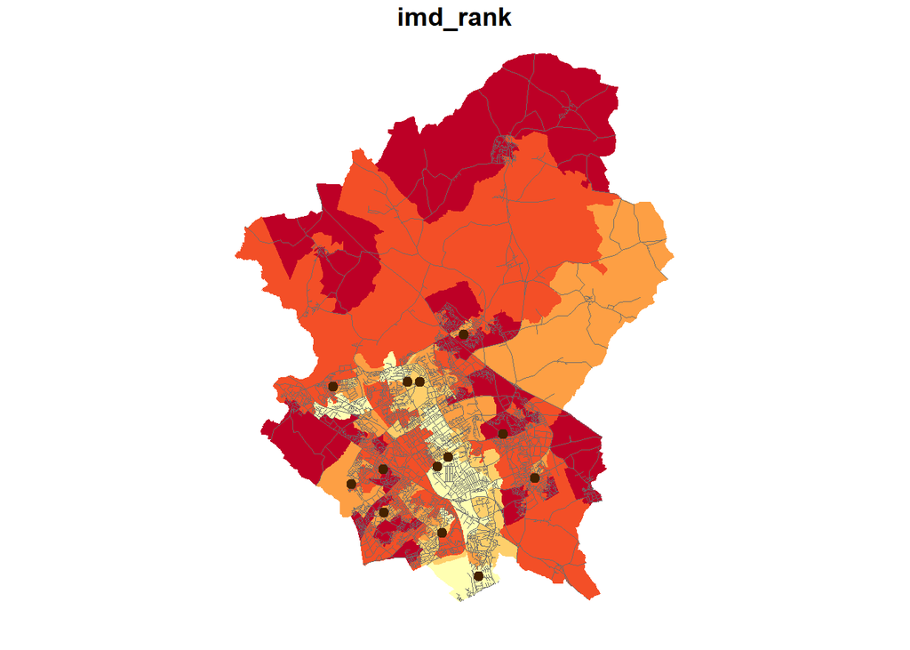

```r
# Plot choropleth
plot(LSOA["imd_rank"],col=colours_to_map,border = NA, reset = FALSE)
plot(st_geometry(roads),col="#6B6B6B",lwd=0.3, add=TRUE, reset=FALSE)
plot(st_geometry(schools_SDF), pch = 19, cex = 1, col = "#442200",add=TRUE)
```

### Plotting a subset of the map

Much in the same way that we can subset a data frame, we can also create subsets of the plot. For example, suppose we just wanted to view a map for a a specific Ward in Milton Keynes.

First we will read in the Ward boundaries.

```r
WARD <- st_read("./data/england_cmwd_2011Polygon.shp")
```

There are 23 wards, which are named as follows.

```r
WARD$name
```

```
##  [1] "Bletchley and Fenny Stratford" "Bradwell"
##  [3] "Campbell Park"                 "Danesborough"
##  [5] "Denbigh"                       "Eaton Manor"
##  [7] "Emerson Valley"                "Furzton"
##  [9] "Hanslope Park"                 "Linford North"
## [11] "Linford South"                 "Loughton Park"
## [13] "Middleton"                     "Newport Pagnell North"
## [15] "Newport Pagnell South"         "Olney"
## [17] "Sherington"                    "Stantonbury"
## [19] "Stony Stratford"               "Walton Park"
## [21] "Whaddon"                       "Wolverton"
## [23] "Woughton"
```

We can plot and label these as follows. The text() function applies text to the map, specifying three lists including the Easting, Northing and the text labels. The Easting and Northing are derived using the st_coordinates() function, which for spatial polygons takes the centre of the polygon extent if you specify st_centroid.

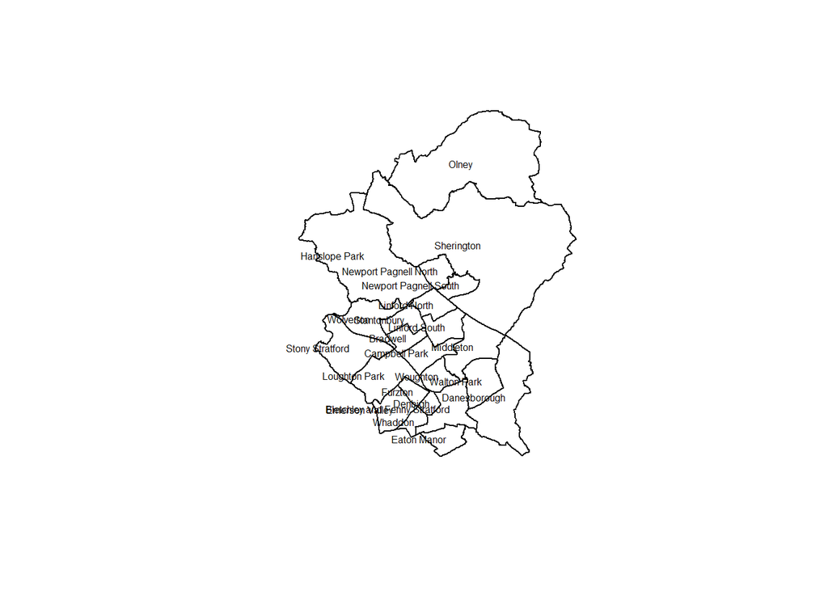

```r
plot(st_geometry(WARD))
#plot(st_centroid(st_geometry(WARD)), add = TRUE, reset=FALSE)

text(st_coordinates(st_centroid(WARD)),WARD$name,cex = 0.5,offset = 0.5, adj = 1)
```

```r
# it doesn't look great so we can move to some more sophisticated libraries
```

In the following example we can use the attributes of the spatial data frame to plot just a small area of the total simple feature data frame object. For example, to plot just Loughton Park we can use the square brackets to just select a single row that matches the name “Loughton Park”

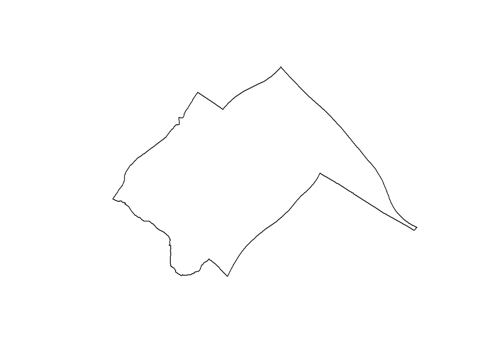

```r
plot(st_geometry(WARD[WARD$name == "Loughton Park",]))
```

This is a useful technique to create a more limited extent. We can use this as follows with some of the previous plots to create a “zoomed in map”. Note how we are building the map up as a series of layers.

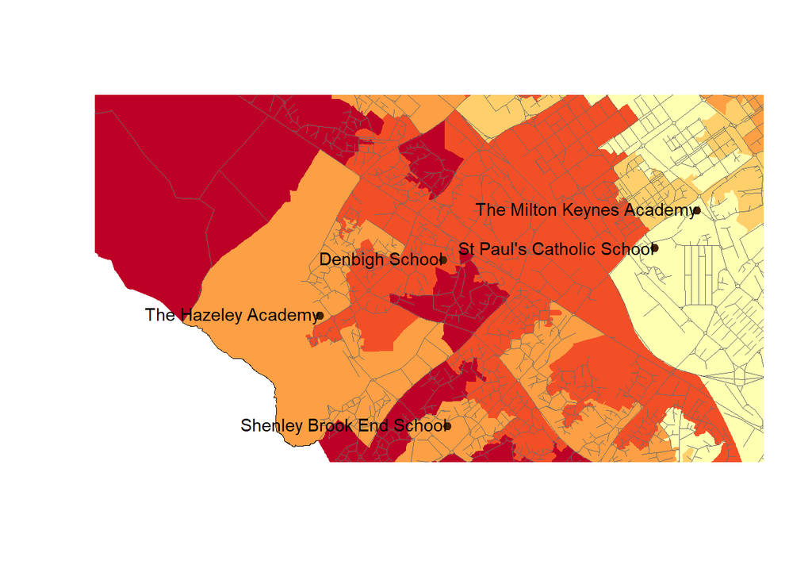

```r
plot(st_geometry(WARD[WARD$name == "Loughton Park",],border=NA, reset=FALSE)) #creates the extent, note that border = NA to make this polygon invisible
plot(LSOA["imd_rank"],col=colours_to_map,border = NA,add=TRUE, reset=FALSE) #plot the choropleth for the IMD
plot(st_geometry(roads),add=TRUE, col="#6B6B6B",lwd=0.3,reset=FALSE) #plot the roads
plot(st_geometry(schools_SDF), pch = 19, cex = 0.9, col = "#442200",add=TRUE) #plot the schools
text(st_coordinates(st_centroid(schools_SDF)),schools_SDF$SCHNAME,cex = 0.9,offset = 0.5, adj = 1)
```

## Choropleth mapping in ggplot2

```r
# Load the ggplot2 package
library(ggplot2)
```

```r
head(LSOA)
```

```
## Simple feature collection with 6 features and 12 fields
## Geometry type: POLYGON
## Dimension:     XY
## Bounding box:  xmin: 484809.9 ymin: 232500 xmax: 488372 ymax: 234990
## Projected CRS: Transverse_Mercator
##    LSOA11CD imd_rank imd_score income employment education health crime housing
## 1 E01016710    11648     23.67   0.20       0.14     28.57   0.47  0.36   17.34
## 2 E01016711    25604      8.87   0.10       0.07     10.62  -0.60 -0.76   19.87
## 3 E01016713    22671     11.27   0.09       0.09     18.38  -0.42 -0.57   18.40
## 4 E01016714     8671     29.07   0.24       0.15     37.17   0.44  0.29   22.76
## 5 E01016715    10843     25.04   0.17       0.14     31.33   0.33  0.79   25.15
## 6 E01016716    11207     24.39   0.19       0.14     24.94   0.57  0.35   18.58
##   living_env idaci idaopi                       geometry
## 1       2.35  0.25   0.23 POLYGON ((487797.2 233640.4...
## 2       2.31  0.17   0.07 POLYGON ((485678.5 233494.2...
## 3       7.72  0.14   0.08 POLYGON ((485628.2 233270.6...
## 4      19.28  0.31   0.22 POLYGON ((487329.3 233184.8...
## 5       3.82  0.22   0.16 POLYGON ((485228.1 233146.6...
## 6      14.52  0.25   0.16 POLYGON ((487502.1 234209.8...
```

We can now use these attributes to create a choropleth map. First we setup the map using ggplot(). We can then tell ggplot how the map should look; firstly stating that the objects are geom_sf (simple features), and then we add some adjustment to the x and y labels, and alter the legend title (“+labs”).

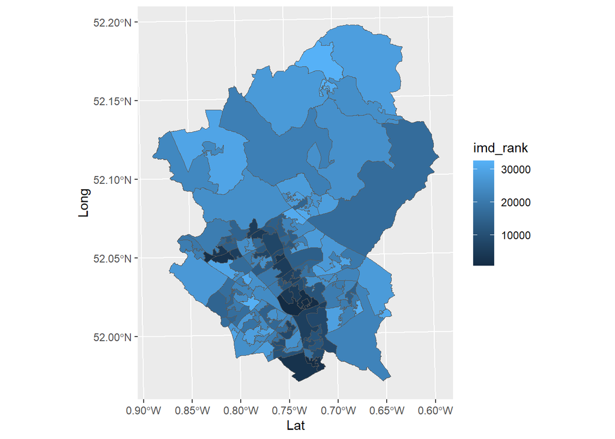

```r
Map<-ggplot(LSOA) +
  geom_sf(aes(fill=imd_rank))+labs(x = "Lat", y = "Long")
Map
```

We can also add layers to the plot as we did in the previous example. We can then add this to the “Map” object we just created, however we will build this up as layers. Rather than specifying LSOA in your initial ggplot brackets you specify it after geom(sf of the individual maps)

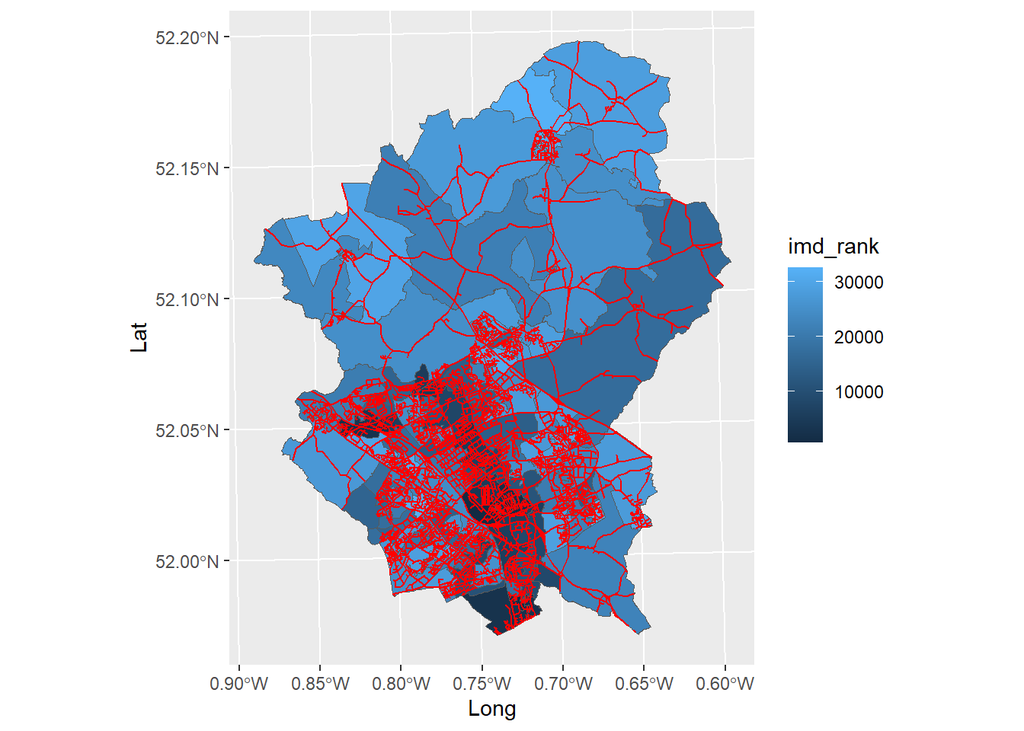

```r
# Create choropleth

ggplot() +
  geom_sf(data=LSOA, aes(fill=imd_rank))+labs(x = "Long", y = "Lat")+
    #geom_sf_text(aes(label = imd_rank), size = 2) +
  geom_sf(data=roads, color = "red")
```

```r
   #geom_text_repel(aes(label = name, geometry = geometry),
```

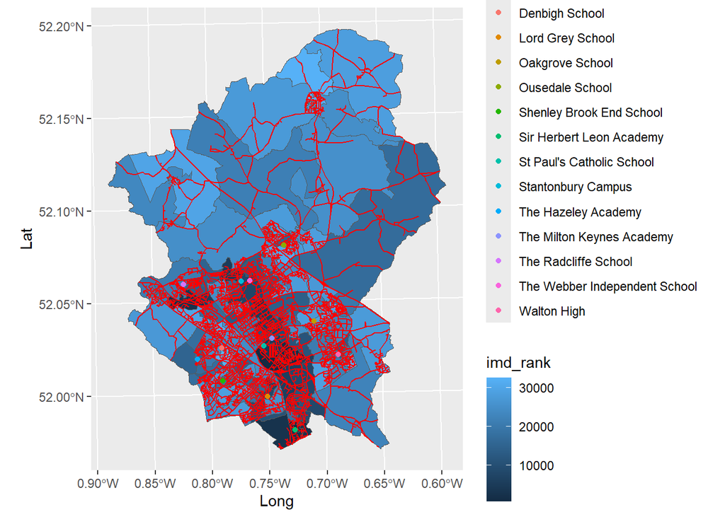

```r
# Create school plot

# Create choropleth

ggplot() +
  geom_sf(data=LSOA, aes(fill=imd_rank))+labs(x = "Long", y = "Lat")+
    #geom_sf_text(aes(label = imd_rank), size = 2) +
  geom_sf(data=roads, color = "red") +
   #geom_text_repel(aes(label = name, geometry = geometry),
geom_sf(data = schools_SDF, aes(color=SCHNAME))
```

Have a look at some cool tutorials on how to use ggplot for sf objects. https://tmieno2.github.io/R-as-GIS-for-Economists/geom-sf.html https://learning.nceas.ucsb.edu/2020-02-RRCourse/spatial-vector-analysis-using-sf.html#visualize-with-ggplot https://geanders.github.io/navy_public_health/3-2-basic-mapping.html

It is also possible to control the other elements of the plot using “theme_bw()” which removes many of the visible elements.

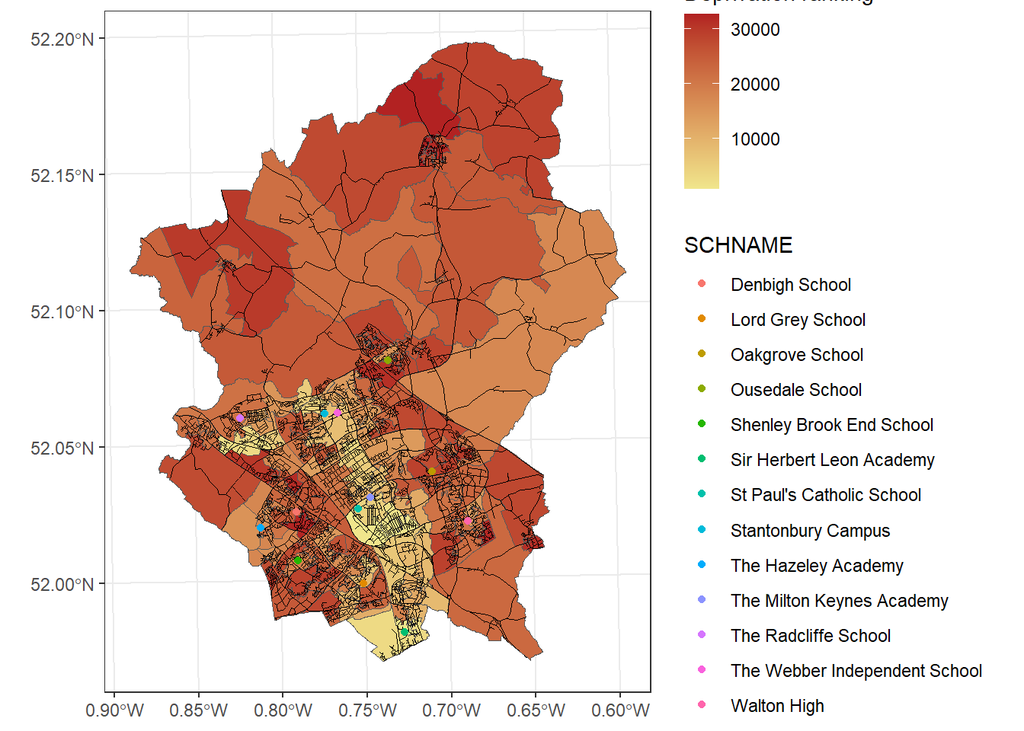

```r
#Create a clean plot
ggplot(LSOA) +
  geom_sf(aes(fill = imd_rank)) +
  theme_bw() +
  labs(fill = "Deprivation ranking") +
  scale_fill_continuous(low = "khaki", high =  "firebrick")+
geom_sf(data=roads, color="black",lwd = 0.1) +
#geom_text_repel(aes(label = name, geometry = geometry),
geom_sf(data = schools_SDF, aes(color=SCHNAME))
```

## Making basic maps using tmap

A recent addition to R for creating maps is the [tmap package](https://cran.r-project.org/web/packages/tmap/vignettes/tmap-nutshell.html). This is quite flexible and can be used to create various types of maps and geographic representations with relative simplicity. For someone starting with R, this is probably the simplest entry point. First we will install and load the package:

```r
install.packages("tmap")
```

```r
library(tmap)
```

We will first load a shapefile for the Leeds, UK.

```r
#Read Shapefile
Leeds <- st_read("./data/E08000035.shp")
# Have a look at the attributes
head(Leeds)
```

```
## Simple feature collection with 6 features and 12 fields
## Geometry type: POLYGON
## Dimension:     XY
## Bounding box:  xmin: 416384.8 ymin: 440997.1 xmax: 421817.5 ymax: 443453.8
## Projected CRS: Transverse_Mercator
##    LSOA11CD imd_rank imd_score income employment education health crime housing
## 1 E01011264    18951     14.69   0.09       0.09     23.87   0.09 -0.48   16.54
## 2 E01011265    22149     11.71   0.08       0.06      7.89   0.12  0.05    9.92
## 3 E01011266    29793      5.46   0.02       0.03      1.01  -1.54 -0.35   27.38
## 4 E01011267     9622     27.18   0.16       0.13     31.45   0.91  0.48   23.35
## 5 E01011268     5862     35.74   0.19       0.19     49.35   1.03  0.51   22.10
## 6 E01011269    15025     19.03   0.12       0.10     22.35   0.22  0.30   13.25
##   living_env idaci idaopi                       geometry
## 1      22.99  0.14   0.08 POLYGON ((421326.9 442029, ...
## 2      29.35  0.08   0.14 POLYGON ((419139.6 441708.1...
## 3      17.77  0.04   0.03 POLYGON ((417620 443437.1, ...
## 4      24.62  0.21   0.18 POLYGON ((419400 442161.3, ...
## 5      32.85  0.19   0.26 POLYGON ((420161 441835.2, ...
## 6      30.23  0.12   0.18 POLYGON ((420546.8 441602.9...
```

```r
#make sure your imd_rank is a numeric value
str(Leeds)
```

```
## Classes 'sf' and 'data.frame':   482 obs. of  13 variables:
##  $ LSOA11CD  : chr  "E01011264" "E01011265" "E01011266" "E01011267" ...
##  $ imd_rank  : num  18951 22149 29793 9622 5862 ...
##  $ imd_score : num  14.69 11.71 5.46 27.18 35.74 ...
##  $ income    : num  0.09 0.08 0.02 0.16 0.19 0.12 0.02 0.04 0.03 0.09 ...
##  $ employment: num  0.09 0.06 0.03 0.13 0.19 0.1 0.05 0.04 0.04 0.09 ...
##  $ education : num  23.87 7.89 1.01 31.45 49.35 ...
##  $ health    : num  0.09 0.12 -1.54 0.91 1.03 0.22 -0.68 -1.37 -0.73 0.44 ...
##  $ crime     : num  -0.48 0.05 -0.35 0.48 0.51 0.3 -0.63 -0.38 -0.94 0.09 ...
##  $ housing   : num  16.54 9.92 27.38 23.35 22.1 ...
##  $ living_env: num  23 29.4 17.8 24.6 32.9 ...
##  $ idaci     : num  0.14 0.08 0.04 0.21 0.19 0.12 0.01 0.04 0.02 0.08 ...
##  $ idaopi    : num  0.08 0.14 0.03 0.18 0.26 0.18 0.03 0.06 0.05 0.17 ...
##  $ geometry  :sfc_POLYGON of length 482; first list element: List of 1
##   ..$ : num [1:833, 1:2] 421327 421323 421323 421321 421321 ...
##   ..- attr(*, "class")= chr [1:3] "XY" "POLYGON" "sfg"
##  - attr(*, "sf_column")= chr "geometry"
##  - attr(*, "agr")= Factor w/ 3 levels "constant","aggregate",..: NA NA NA NA NA NA NA NA NA NA ...
##   ..- attr(*, "names")= chr [1:12] "LSOA11CD" "imd_rank" "imd_score" "income" ...
```

We will store the map in the “M” object - first we setup the map and projection - note that we use the CRS 27700 which is the code for the British National Grid:

```r
m <- tm_shape(Leeds, projection=27700)
```

```
## ── tmap v3 code detected ───────────────────────────────────────────────────────
```

```
## [v3->v4] `tm_shape()`: use `crs` instead of `projection`.
```

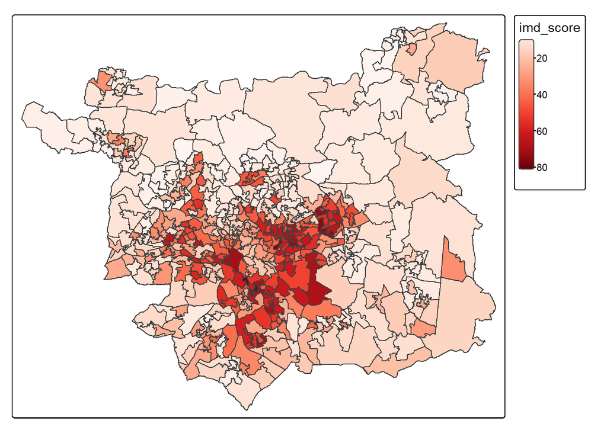

```r
# commented out are v3 tmap maps :)
#m <- tm_shape(Leeds, projection=27700) +
#   tm_polygons(col="imd_score", style="equal",n=5,border.col = "grey50",  border.alpha = .5, title="IMD Quintile", showNA=FALSE,palette="Blues")
#Print plot
#m
m<-tm_shape(Leeds, crs=27700) +
  tm_polygons(
    fill = "imd_score",
    fill.scale = tm_scale_continuous(
      values = "brewer.reds"))
m
```

We can then add some final options with tm_layout() to remove the frame around the plot:

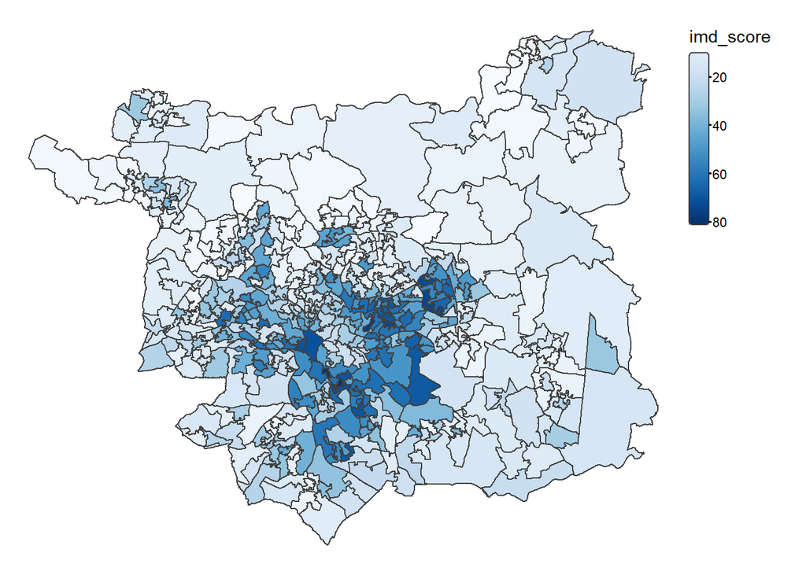

```r
m<-tm_shape(Leeds, crs=27700) +
  tm_polygons(
    fill = "imd_score",
    fill.scale = tm_scale_continuous(
      values = "brewer.blues"))+
  tm_layout(
    frame = FALSE,
    legend.frame = FALSE)

#Print plot
m
```

As with the ggplot2 and base R maps, it is also possible to build up layers and use lines or points to add context to the maps. Here we replicate the map shown earlier:

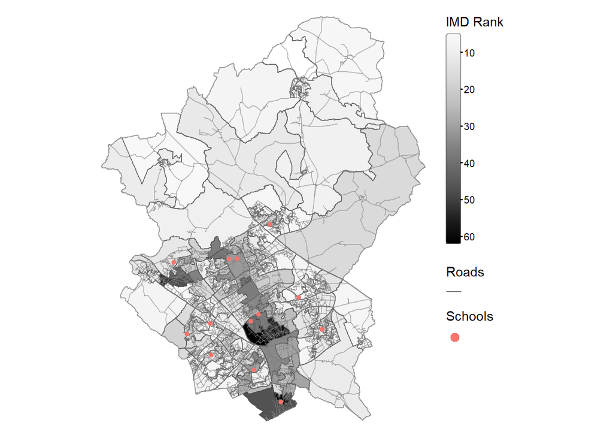

```r
tm_shape(LSOA, crs = 27700) +
    tm_polygons(fill = "imd_score",fill.scale = tm_scale_continuous(values = "brewer.greys"),col_alpha = .5, fill.legend = tm_legend("IMD Rank"))+

# Add roads
  tm_shape(roads) +
    tm_lines(lwd.scale = 2, col = "grey50",col_alpha = 0.5)  +
    tm_add_legend(type="lines", col="grey50", title="Roads") +
#Add schools
#Add schools
tm_shape(schools_SDF) +
    tm_symbols(size=0.5,shape=20, fill = "#f7756d") +
    tm_add_legend(type="symbols", shape=20, fill ="#f7756d", title="Schools") +
#Remove the frame and set legend position
    tm_layout(legend.outside=TRUE, frame = FALSE, component.autoscale = FALSE, legend.frame=FALSE)
```

### Alternative types of map

So far we have only considered creating contextual choropleth maps, however, tmap is also useful to create a number of alternative map types including proportional symbol maps and cartograms.

First we will import a file of ward centroids which has a “Crimes” attribute that records the number of recorded crimes within the ward during August 2016.

```r
# Read in crime data
Crimes_SP <- st_read("./data/crimes.shp")
# Read in crime data; and set crimes as a numeric
str(Crimes_SP)
```

```
## Classes 'sf' and 'data.frame':   33 obs. of  3 variables:
##  $ Zone    : chr  "00DAGL" "00DAGM" "00DAGN" "00DAGP" ...
##  $ Crimes  : num  114 143 152 516 435 ...
##  $ geometry:sfc_POINT of length 33; first list element:  'XY' num  425940 442832
##  - attr(*, "sf_column")= chr "geometry"
##  - attr(*, "agr")= Factor w/ 3 levels "constant","aggregate",..: NA NA
##   ..- attr(*, "names")= chr [1:2] "Zone" "Crimes"
```

```r
# if crimes are not numeric change the character to num
Crimes_SP$Crimes <- as.numeric(as.character(Crimes_SP$Crimes))
```

The following code first creates the choropleth with tm_polygons(), and then appends the bubbles using tm_bubbles() based on the “Crimes” attribute.

```r
tm_shape(Leeds, crs = 27700) +
    tm_polygons(fill = "imd_score", fill.scale = tm_scale_intervals(values = "brewer.greys",5,style = "equal"), col_alpha = .5, fill.legend = tm_legend("IMD Rank"))+
    # Add scaled bubbles
tm_shape(Crimes_SP) +
    tm_bubbles("Crimes",col="blue", title.size = "Crimes")+

  # Add legend and remove borders
tm_layout(frame = FALSE,legend.text.size = 0.65)
```

```
## ── tmap v3 code detected ───────────────────────────────────────────────────────
```

```
## [v3->v4] `tm_bubbles()`: use 'fill' for the fill color of polygons/symbols
## (instead of 'col'), and 'col' for the outlines (instead of 'border.col').
```

[figure not shown]

A further type of map that tmap can create is a cartogram; which is actually imported from the cartogram package. This type of representation scales each of the zones by an absolute measure such as population. Thus, zones with low counts become smaller and high counts larger. There are a lot of algorithms to make [cartograms](https://en.wikipedia.org/wiki/Cartogram), however, the implementation within tmap is the commonly used continuous area cartogram.

We will therefore import some population data and append these to the spatial polygons data frame created earlier called “Leeds”:

```r
#Read population data
Leeds_pop <- read.csv("./data/Leeds_Census_2011.csv")

#Join to spatial polygon dataframe
Leeds <- merge(Leeds, Leeds_pop, by.x = "LSOA11CD", by.y = "Code")
```

The following code creates the cartogram, however, takes a long time to run. If using this function, then this time increases the more complex and large the set of polygons. An alternative but free non R solution is [ScapeToad](http://scapetoad.choros.ch/).

```r
library(cartogram)
Leeds_Cartogram <- cartogram_cont(Leeds, "Usual_Residents_2011", itermax = 15, maxSizeError = 1.0001,prepare = "adjust", threshold = 0.05) # Takes a long time to process
```

# Further resources / training

- [An Introduction to R for Spatial Analysis and Mapping](https://uk.sagepub.com/en-gb/eur/an-introduction-to-r-for-spatial-analysis-and-mapping/book241031) - a great primer on mapping in R
- [ggplot2 book](http://ggplot2.org/book/) - code and sample chapters for the [book](http://www.springer.com/gb/book/9780387981413)
- [Scape Toad](http://scapetoad.choros.ch/) - A great tool for creating cartograms